# sulfate & male vs FEV

T Smith

2026-07-07

```r
chs_data <- read.csv("CHS_cohortE(in).csv")
```

## Since I have now ran signifcance and strongest predictor test, i’ll now run correlations between sulfate (neg predictor) vs FEV & male (pos predictor) vs FEV

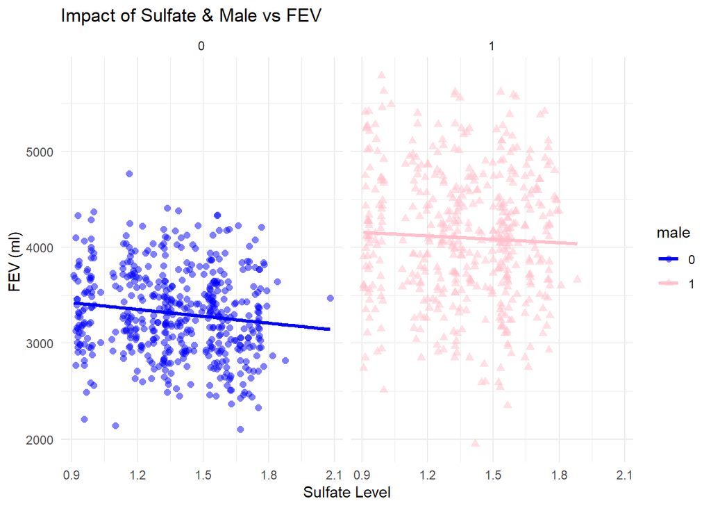

```r
library(ggplot2)
library(dplyr)
chs_sex <- chs_data %>% mutate(male = as.factor(male))

ggplot(chs_sex, aes(x = sulfate, y = fev1, color = male, shape = male)) +
  geom_point(alpha = 0.5, size = 2) +
  geom_smooth(method = "lm", se = FALSE, linewidth = 1.2) +
  scale_color_manual(values = c("blue", "pink")) +
  theme_minimal() +
  labs(
    title = "Impact of Sulfate & Male vs FEV",
    x = "Sulfate Level",
    y = "FEV (ml) ",
    color = "male",
    shape = "male"
  ) +
facet_wrap(~male)
```

## Looking at the plots side by side male (pink 1) has an overall higher baseline FEV than female(blue 0). The points on pink sit visually closer to 4000ml than blue (closer to 3000ml). Both groups show a negative relation between sulfate and FEV (downward slopes). Sulfate levels rise, lung function (FEV) slightly drops for everyone. The regression lines look nearly parallel so both genders are affected similarly.

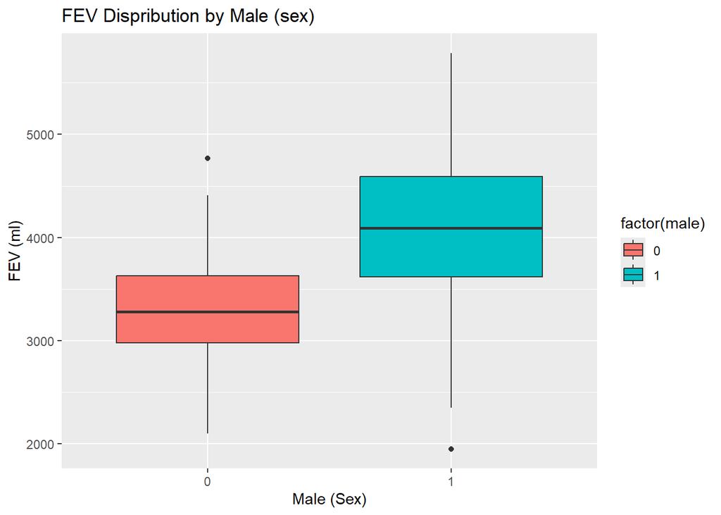

```r
ggplot(chs_data, aes(x = factor(male), y =fev1, fill = factor(male))) +
  geom_boxplot() +
  labs(
    title = "FEV Dispribution by Male (sex)",
    x = "Male (Sex)",
    y = "FEV (ml)"
  )
```

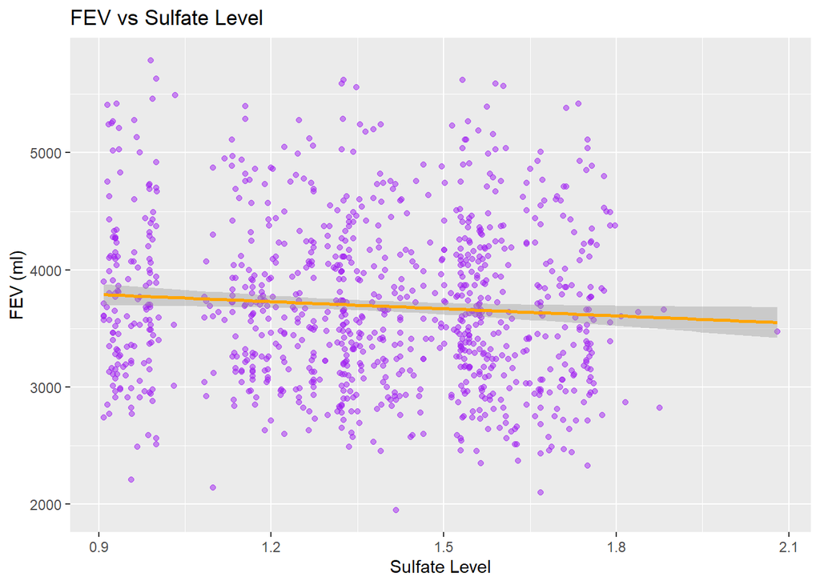

```r
ggplot(chs_data, aes(x = sulfate, y =fev1)) +
  geom_point(alpha = 0.5, color = "purple") +
  geom_smooth(method = "lm", color = "orange", se = TRUE) +
  labs(
    title = "FEV vs Sulfate Level",
    x = "Sulfate Level",
    y = "FEV (ml)"
)
```

## With this scatter plot i notice the regression line slightly slopes down from left to right, showing that as sulfat levels increase = FEV levels tend to slightly decrease. Looking at the points being wide spread and slope being almost flat I would say while sulfate is a statistically significant predictor in the model it doesnt explain all the massive variation in lung function (FEV) alone.

## To see how the downward slope shows for male vs female i’ll make a plot comparing the 2

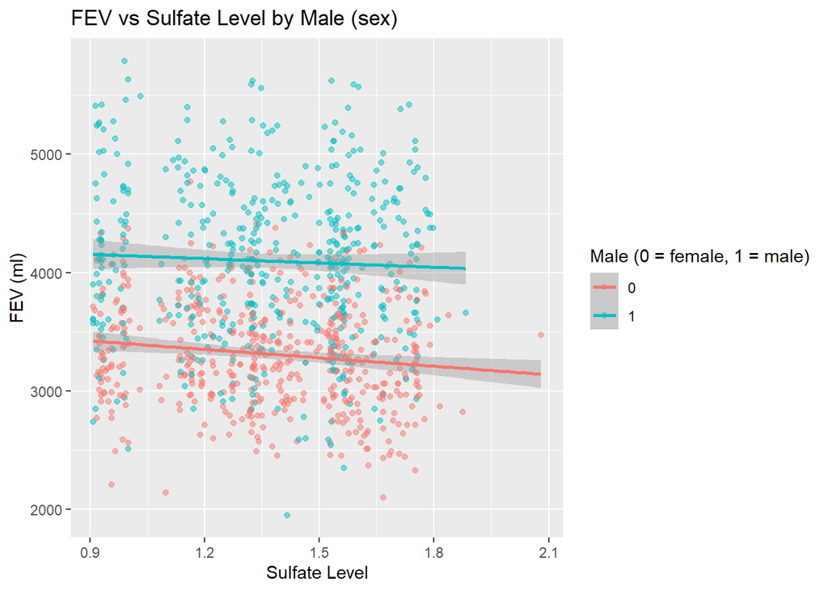

```r
ggplot(chs_data, aes(x = sulfate, y = fev1, color = factor(male))) +
  geom_point(alpha = 0.5) +
  geom_smooth(method = "lm", se = TRUE) +
  labs(
    title = "FEV vs Sulfate Level by Male (sex)",
    x = "Sulfate Level",
    y = "FEV (ml)",
    color = "Male (0 = female, 1 = male)"
  )
```